# Interaction of R0 and Refractory Period & impact on endemicity

### How do R0 and the Refractory Period interact, and what is the impact on disease endemicity?

#### Model Parameters

In order to explore interaction between $R0$ and refractory period, and impact on model behaviour and endemicity:

- $k = Inf$ a baseline homogeneous population
- Heterogeneity in transmission potential is fixed over time
- Include reseeding of infection to prevent early stochastic extinction
- $Generations = 1000$ to observe endemicity

```r
## Model Definition ##
runs <- 100
generations <- 1000 # the number of generations (or timesteps) to run the model over
output <- "I_counts" # defines the output as "matrix" (full disease state and ID of units) or "counts" (number of units in S,I,R states or "I_counts" (returns only count of infected units over time)

## Population Parameters ##

N <- 10000 # population size (may exxclude in favour of calculating in state_update function)
I0 <- 10
state_tracker <- c(rep("I", I0), rep("S", N - I0)) # initial disease state of units in population
population_sample <- "large" # large or small population (determines sampling strategy)

## Epidemiological Parameters ##

R_period <- Inf # the refractory period: 1 = no immunity, Inf = lifelong immunity
R0_estimate <- 3 # average number of effective contacts per unit
k_transmission <- Inf # overdispersion parameter, level of heterogeneity in effective contact potential: 0.1 = high heterogneiety, Inf = homogeneous

heterogeneity <- "fixed" # "fixed" or "variable", is unit transmission potential constant through time?
contact_list1 <- replicate(N, c(1:N), simplify = FALSE)
contact_list <- lapply(1:length(contact_list1),
                       function(x) contact_list1[[x]][-x])

## Reseeding Parameters ##
reseed <- TRUE # reseed 5 infections periodically during the first 10% of generations
reseed_threshold <- 100 # threshold generation for reseeding events
reseed_frequency <- 10
introductions <- 10 # number of new cases introduced when reseeding occurs

## Vaccination Parameters ##
V_prop <- 0 # proportion to be vaccinated in each round
V_start <- 0 # start generation for vaccination
V_period <- 0 # duration of immunity from vaccination (by number of timesteps)
V_rounds <- 0 # number of rounds (-1 for starting round) of vaccination in programme
V_schedule <- 0 # how frequent is vacciantion (ie every 2 "years")
V_mode <- "random" #random, target or non_target, NB: target/non-target only possible if heterogneiety is fixed
```

### Model Results:

#### Plot 1 : Median Incidence at Equilibrium

**Plot showing how the median incidence+ IQR (after 900 generations) is impacted by R0 (x axis) and refractory period (facets)**

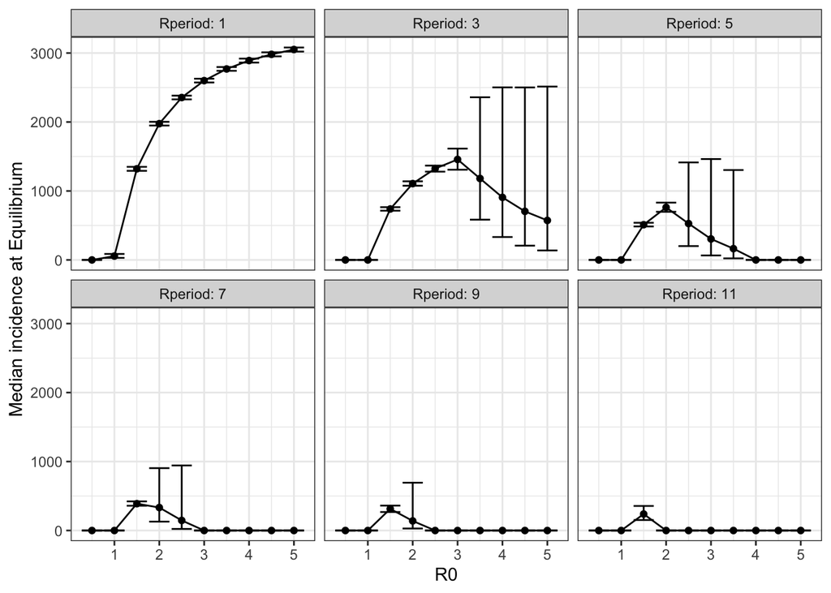

**How do $R0$ and Refractory Period impact incidence at equilibrium (900 generations)**

For a given refractory period

- At values of $R0 <1$ extinction occurs in all cases
- At $R0 = 1$ extinction occurs in all cases, except when the refractory period is 1 generation (i.e. very short-lived immunity)
- At values of $R0 > 1$:
  - the median incidence at equilibrium increases, as R0 increases up to a threshold $R0$ value at which the median incidence reaches a maximum
  - At values of $R0$ above the threshold, the median incidence at equilibirum (900Gs) decreases as $R0$ increases, to eventual extinction for high values of $R0$
  - The threshold $R0$ value (max incidence) varies depending on the refractory period. For longer refractory periods, the threshold (max incidence) occurs at lower values of R0.
  - As the refractory period increases, the maximum incidence (at equilibrium) decreases (from ~3000cases per generation for a refractory period of 1 and $R0 = 5$, to ~200cases per generation for a refractory period of 11 and $R0 = 1.5$)
- Variation around median incidence:
  - At values of $R0$ below the threshold (mx incidence) there is low variation in median incidence, indicating that a stable equilibrium is attained.
  - At values of $R0$ above the threshold (mx incidence) there is a much greater degree of variation in median incidence (indicated by the interquartile range) up to the point of extinction. This reflects a large oscillations (sharp increases and decreases in incidence, as the susceptible population is depleted and replenished) and failure to reach a stable equilibrium (see below for individual trajectories).
- Extinction:
  - As the refractory period increases, the value of $R0$ at which extinction occurs, decreases ( from $R0 > 5$ when the refracotry period is 3 generations to $R0 \approx 2.0$ when the refractory period is 11 generations)

##### Individual Epidemic Trajectories

**Oscillatory behaviour beyond R0 threshold (max Incidence)**

- Explore trajectories of individual simulations under selected scenarios, where oscillatory behaviour is suggested by large IQR.
  - Refractory Period = 3, R0 = 3.5 - 5 (see previous plot)
- Is oscillatory behaviour maintained longterm or does incidence reach stable equilibrium

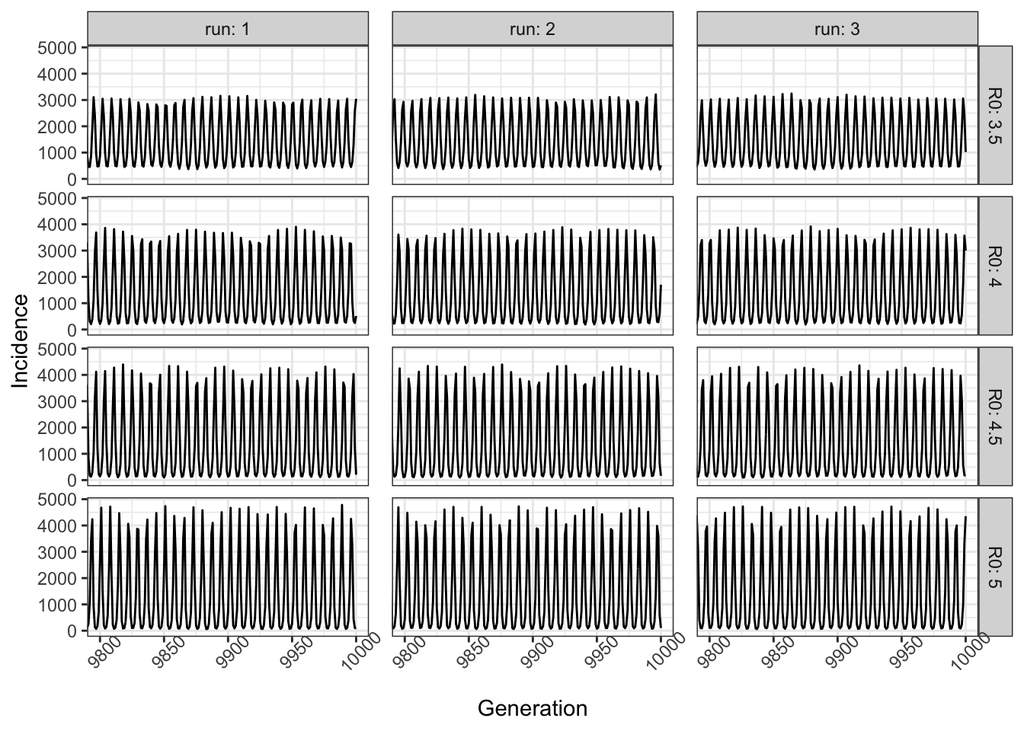

**Long term trajectories**

Note: The above simulations were run for 10,000 generations to observe true long-term behaviour

- Oscillatory behaviour is maintained long-term (up to 10000 generations), with no stable equilibrium is reached.
- The large IQR of epidemic scenarios with an R0 > threshold (max incidence) reflects oscillations around the median incidence
  - Higher values of $R0$ lead to rapid spread of infection throughout population, and hence rapid depletion of the susceptible population. Together with (short-term) sustained immunity this results in declining incidence as infection spread is limited by the reduced susceptible population.
  - The susceptible population is replenished as units lose their immunity, with epidemic growth and rapid increase in incidence occuring once the susceptible population has been replenished sufficiently to sustain epidemic growth.

#### Plot 2 : Proportion of simulations which become endemic

**Shade of blue and size of point indicates median incidence**

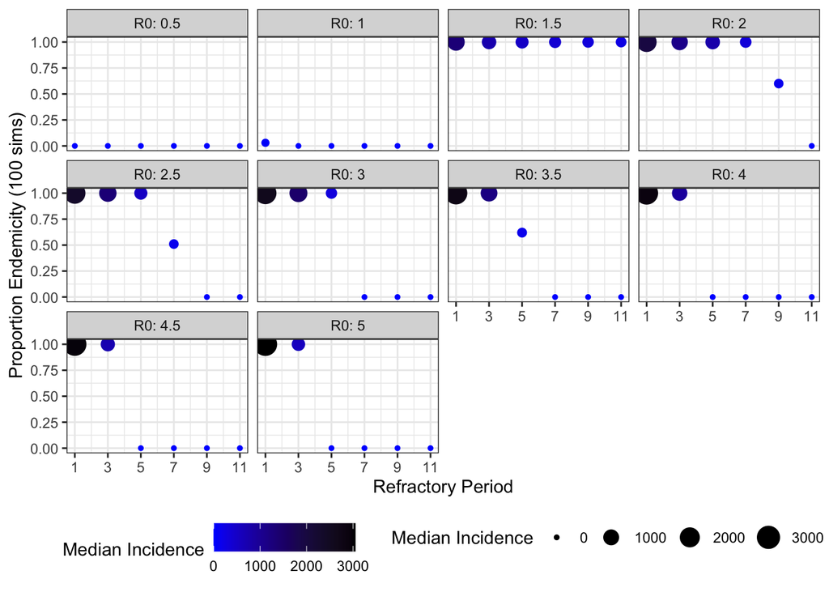

**What is the impact of $R0$ and refractory period on endemicity?**

In all cases, for a given value of R0 the median incidence decreases with an increasing refractory period (as shown in the previous plot)

For $R0 < 1$

- All simulations result in extinction

For $R0 = 1.5$

- All simulations result in endemicity. This may reflect the narrow range of Refractory Periods evaluated (maximum Refractory Period = 11 generations)

For $R0 > 1.5$

**Why are there some scenarios where a proportion of simulations become extinct?**

Parameter scenarios with mixed outcomes:

- R0 = 2, RP = 9
- R0 = 2.5, RP = 7
- R0 = 3.5, RP = 5
- *NB: scenarios above are limited by parameter values evaluated*

Explanation (see plot below):

- Extreme oscillation about median incidence
- Trough of epidemic reaches very low incidence
- Stochastic die-out possible during low incidence trough, if chance infection of units with low/no onward transmission.
- Extreme fluctuation, explained above, is result of rapid spread of epidemic and sustained immunity in population which depletes the susceptible population such that incidence declines. At v low incidence, susceptible population is replenished as previously infected individuals lose immunity, hence infection can spread again throughout population.

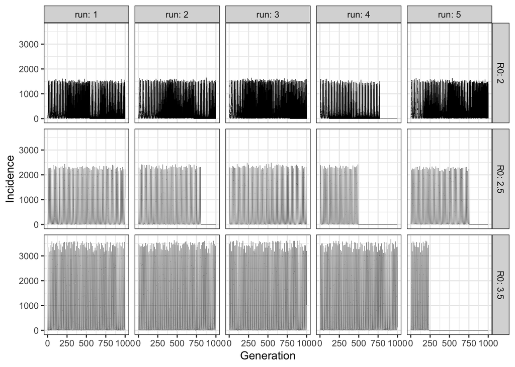